# Lab 2: June 26

Author

Khoa Tran

```r
library(tidyverse)
library(gsheet)
```

A large credit union awards quarterly bonuses to its employees. To ensure fairness across departments, data on the bonuses are regularly reviewed for equality. Consider the data in the following Google Sheet, which includes the bonus percentage for each employee in two departments.

```r
data <- as_tibble(gsheet2tbl("https://docs.google.com/spreadsheets/d/1q0Ouhr6hGBDp-5oyQuYGcsWTLrsayywVHJS7o17Sm6Y/edit?usp=sharing"))
head(data)
```

```
# A tibble: 6 × 2
  Department Bonus
  <chr>      <dbl>
1 Mortgage     9.2
2 Mortgage     7.7
3 Mortgage    11.9
4 Mortgage     6.2
5 Mortgage     9
6 Mortgage     8.4
```

**1. Estimate each group mean using the sample means and 99% confidence intervals. (i.e., provide a 99% CI for $\mu_{\text{mortgage}}$, and, separately, a 99% CI for $\mu_{\text{credit}}$.) Remember to state the group means and corresponding CIs.**

```r
mortgage_data <- data[data$Department == "Mortgage", "Bonus"]
credit_data <- data[data$Department == "Credit", "Bonus"]
t.test(mortgage_data, conf.level = 0.99)
```

```
    One Sample t-test

data:  mortgage_data
t = 35.161, df = 23, p-value < 2.2e-16
alternative hypothesis: true mean is not equal to 0
99 percent confidence interval:
 7.852006 9.214660
sample estimates:
mean of x
 8.533333
```

```r
t.test(credit_data, conf.level = 0.99)
```

```
    One Sample t-test

data:  credit_data
t = 57.877, df = 35, p-value < 2.2e-16
alternative hypothesis: true mean is not equal to 0
99 percent confidence interval:
  9.227618 10.139049
sample estimates:
mean of x
 9.683333
```

Group mean for Mortgage is 8.53 and for the 99% CI it is (7.85, 9.21). Group mean for Credit is 9.68 and the 99% CI for credit is (9.23, 10.14).  
**2. Estimate the average difference in bonuses for the two departments using the sample mean and 99% confidence interval for the difference in bonuses for the two departments. Remember to state the mean and corresponding CI.**

```r
t.test(Bonus ~ Department, data=data, conf.level = 0.99, var.equal = TRUE)
```

```
    Two Sample t-test

data:  Bonus by Department
t = 4.0367, df = 58, p-value = 0.0001609
alternative hypothesis: true difference in means between group Credit and group Mortgage is not equal to 0
99 percent confidence interval:
 0.3912754 1.9087246
sample estimates:
  mean in group Credit mean in group Mortgage
              9.683333               8.533333
```

**3. Use the appropriate hypothesis test to determine if the two departments are given different bonus amounts. Test at the $\alpha=0.01$ level. Remember to typeset the results.**

```r
t.test(Bonus ~ Department, data=data, alternative = "two")
```

```
    Welch Two Sample t-test

data:  Bonus by Department
t = 3.9013, df = 43.587, p-value = 0.000327
alternative hypothesis: true difference in means between group Credit and group Mortgage is not equal to 0
95 percent confidence interval:
 0.5557583 1.7442417
sample estimates:
  mean in group Credit mean in group Mortgage
              9.683333               8.533333
```

- **Hypotheses**
  - $H_0:mu_{Credit} [$equals$] mu_{Mortgage}$
  - $H_1:mu_{Credit} [$does not equal$] mu_{Mortgage}$
- **Test Statistic and *p*-Value**
  - $t_0 = 3.9013$
  - $p = 0.000327 <0.001$
- **Rejection Region**
  - Reject $H_0$ if $p < \alpha$; $alpha = 0.01$.
- **Conclusion/Interpretation**
  - [Reject] $H_0$. There [is] sufficient evidence to suggest the two departments are given different bonus amounts.

**4. (Challenge! …but required!) Construct a graph that will help you explain your findings to management.**

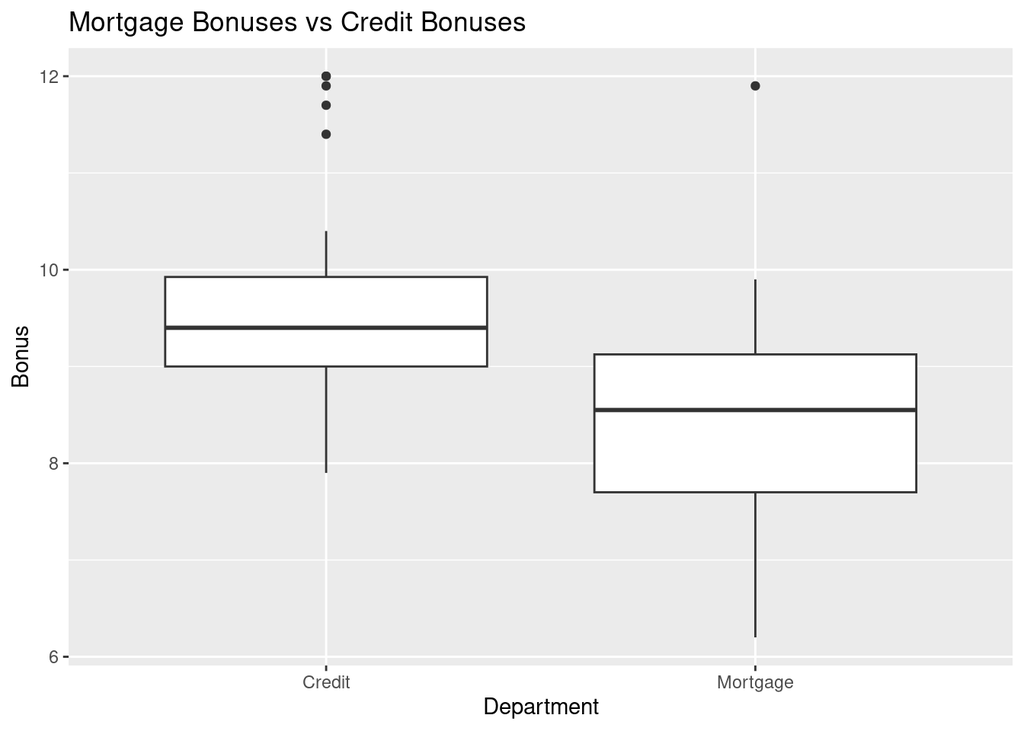

```r
ggplot(data, aes(x = Department, y = Bonus)) +
  geom_boxplot() +
  labs(x = "Department", y = "Bonus") +
  ggtitle("Mortgage Bonuses vs Credit Bonuses")
```

By using the boxplot graph, you can see that the medians of the two departments. Since the Credit Department had a higher median it means that the average bonuses are higher compared to the Mortgage department.

A new 2 hour reading comprehension program has been developed by a local tutoring center. A pilot study of 30 students has been conducted and we have data on a reading comprehension test taken before the program and a separate reading comprehension test taken after the program. Consider the data, found in the following Google Sheet.

```r
data <- as_tibble(gsheet2tbl("https://docs.google.com/spreadsheets/d/1ijxX7c6qcFAw-r_mNSxC-Ps5b5njw-WtE4RcxPTySXU/edit?usp=sharing"))
head(data)
```

```
# A tibble: 6 × 3
  Student   Pre  Post
    <dbl> <dbl> <dbl>
1       1    71    78
2       2    70    75
3       3    66    68
4       4    85    92
5       5    60    55
6       6    72    74
```

**5. Estimate each group mean using the sample means and 95% confidence intervals. (i.e., provide a 95% CI for $\mu_{\text{pre}}$, and, separately, a 95% CI for $\mu_{\text{post}}$.) Remember to state the group means and corresponding CIs.**

```r
t.test(data$Pre, conf.level = 0.95)
```

```
    One Sample t-test

data:  data$Pre
t = 34.246, df = 29, p-value < 2.2e-16
alternative hypothesis: true mean is not equal to 0
95 percent confidence interval:
 67.16718 75.69949
sample estimates:
mean of x
 71.43333
```

```r
t.test(data$Post, conf.level = 0.95)
```

```
    One Sample t-test

data:  data$Post
t = 31.008, df = 29, p-value < 2.2e-16
alternative hypothesis: true mean is not equal to 0
95 percent confidence interval:
 70.27112 80.19555
sample estimates:
mean of x
 75.23333
```

**6. Estimate the increase in test scores using the sample mean and corresponding 95% confidence interval for the increase in test scores. (i.e., we are interested in estimating $\mu_{\text{post}-\text{pre}}$.**

```r
t.test(data$Post,data$Pre,
paired = TRUE,
conf.level = 0.95)
```

```
    Paired t-test

data:  data$Post and data$Pre
t = 4.9496, df = 29, p-value = 2.918e-05
alternative hypothesis: true mean difference is not equal to 0
95 percent confidence interval:
 2.229795 5.370205
sample estimates:
mean difference
            3.8
```

The increase in test scores using the sample mean and corresponding 95% confidence interval is 3.8 where the 95% confidence interval is (2.23, 5.37).

**7. Use the appropriate hypothesis test to determine if the program raises comprehension test averages by at least 5 points. Test at the $\alpha=0.05$ level. Remember to typeset the results**

```r
t.test(data$Post, data$Pre, mu=5, alternative = "greater")
```

```
    Welch Two Sample t-test

data:  data$Post and data$Pre
t = -0.37504, df = 56.724, p-value = 0.6455
alternative hypothesis: true difference in means is greater than 5
95 percent confidence interval:
 -1.550302       Inf
sample estimates:
mean of x mean of y
 75.23333  71.43333
```

- **Hypotheses**
  - $H_0:mu [$less or equal to$] 5$
  - $H_1:mu [$greater or equal to$] 5$
- **Test Statistic and *p*-Value**
  - $t_0 = -0.37504$
  - $p = 0.6455 > 0.005$
- **Rejection Region**
  - Reject $H_0$ if $p < \alpha$; $alpha = 0.05$.
- **Conclusion/Interpretation**
  - Fail to reject null hypothesis at the alpha = 0.05 level since p-value > 0.05.. There is not enough evidence to suggest that the program raises comprehension test averages by at least 5 points

**8. (Challenge! …but required!) Construct a graph that will help you explain your findings to the tutoring center.**

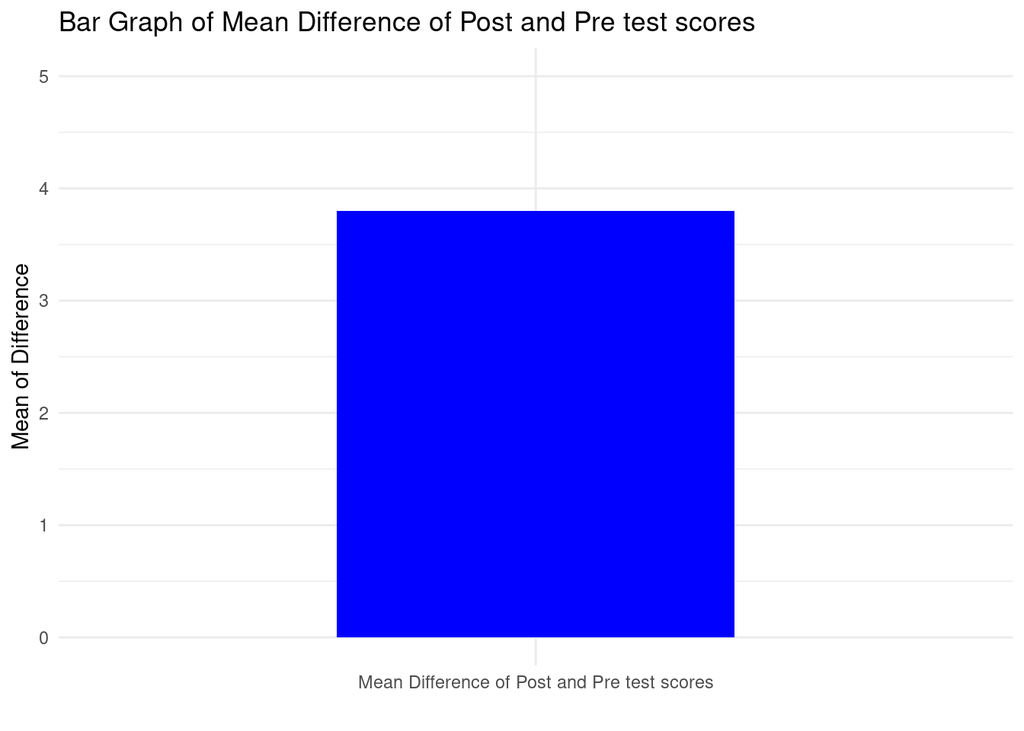

```r
mean_diff <- mean(data$Post)- mean(data$Pre)
ggplot() +
  geom_bar(aes(x = "Mean Difference of Post and Pre test scores", y = mean_diff), stat = "identity", fill = "blue",width = 0.5) +
  labs(title = "Bar Graph of Mean Difference of Post and Pre test scores", x = "", y = "Mean of Difference") +
  theme_minimal() +
   ylim(0, 5)
```